# 대한민국 제21대 국회의원 선거

매니페스토: 국회의원평가

[Tidyverse Korea](https://www.facebook.com/groups/tidyverse/)

2020-04-02

# 1 매니페스토(Manfesto)

위키백과사전 [매니페스토(Manifesto)](https://ko.wikipedia.org/wiki/매니페스토)는 개인이나 단체가 대중에 대하여 확고한 정치적 의도와 견해를 밝히는 것으로 연설이나 문서의 형태로 어원은 라틴어에서 파생된 이탈리아어이며 “분명한 의미”, “매우 뚜렷함”이라는 의미를 갖는다. 중요한 매니페스토들로 미국 독립선언서에 영향을 준 벨기에 독립선언서 “the Manifesto of the Province of Flanders (1790년)”, 핵과 핵전쟁에 대한 반대를 표명한 “Russell-Einstein Manifesto(러셀-아인슈타인 선언, 1955년)”을 꼽을 수 있다.

[한국매니페스토 실천본부](http://manifesto.or.kr/?page_id=3614)는 공약정보센터를 통해서 국회의원, 대통령, 지방자치단체장에 대한 매니페스토 실천이행여부를 점검하고 있다.

# 2 대상목록 데이터

한국매니페스토 실천본부 [제20대 국회의원 공약이행자체평가표(2020년)](http://manifesto.or.kr/manifesto_data/20200210/2020na_map.htm) 웹사이트에서 제20대 국회의원 평가데이터를 다운로드 받는다.

```r
manifesto_url <- "http://www.manifesto.or.kr/manifesto_data/20200210/2020/2020_251.zip"
```

[제20대 국회의원 공약이행자체평가표(2020년)](http://manifesto.or.kr/manifesto_data/20200210/2020na_map.htm) 웹사이트가 깔끔하게 정리되어 있는데 시도별로 나눠줘있다.

[figure not shown]

```r
webshot2::webshot("http://manifesto.or.kr/manifesto_data/20200210/2020na_map.htm", "fig/manifesto_2020.png")
```

## 2.1 특정 시도

먼저 특정시도를 하나 잡아서 이를 데이터프레임으로 만든다.

```r
library(tidyverse)
library(rvest)

manifest_html <- read_html("http://www.manifesto.or.kr/manifesto_data/20200210/20na/01.html")

manifest_tbl <- manifest_html %>%
  html_nodes("table") %>%
  html_table(fill=TRUE) %>%
  .[[1]]

manifest_df <- manifest_tbl %>%
  janitor::clean_names() %>%
  tbl_df %>%
  set_names(manifest_tbl[1,]) %>%
  slice(2:n())

manifest_df %>%
  DT::datatable()
```

|  | 순번 | 지역 | 지역구 | 이름 | 2016년의정계획서 | 2018년평가정보 | 2020년평가정보 |
| --- | --- | --- | --- | --- | --- | --- | --- |
| 1 | 1 | 서울 | 종로구 | 정세균 | 다운받기 | - | 대상아님 |
| 2 | 2 | 서울 | 중구성동구갑 | 홍익표 | 다운받기 | 다운받기 | 다운받기 |
| 3 | 3 | 서울 | 중구성동구을 | 지상욱 | 다운받기 | 다운받기 | 다운받기 |
| 4 | 4 | 서울 | 용산구 | 진영 | 다운받기 | 다운받기 | 대상아님 |
| 5 | 5 | 서울 | 광진구갑 | 전혜숙 | 다운받기 | 다운받기 | 다운받기 |
| 6 | 6 | 서울 | 광진구을 | 추미애 | 다운받기 | 다운받기 | 대상아님 |
| 7 | 7 | 서울 | 동대문구갑 | 안규백 | 다운받기 | 다운받기 | 다운받기 |
| 8 | 8 | 서울 | 동대문구을 | 민병두 | 다운받기 | 다운받기 | 다운받기 |
| 9 | 9 | 서울 | 중랑구갑 | 서영교 | 다운받기 | 다운받기 | 다운받기 |
| 10 | 10 | 서울 | 중랑구을 | 박홍근 | 다운받기 | 다운받기 | 다운받기 |

[output cut: 39 more lines]

## 2.2 함수

특정시도를 하나 잡아서 이를 데이터프레임을 제작한 다음 이를 함수로 만든다.

```r
get_manifesto_list <- function(sido) {

  manifesto_sido_url <- glue::glue("http://www.manifesto.or.kr/manifesto_data/20200210/20na/{sido}.html")
  manifest_html <- read_html(manifesto_sido_url)

  manifest_tbl <- manifest_html %>%
    html_nodes("table") %>%
    html_table(fill=TRUE) %>%
    .[[1]]

  manifest_df <- manifest_tbl %>%
    janitor::clean_names() %>%
    tbl_df %>%
    set_names(manifest_tbl[1,]) %>%
    slice(2:n())

  return(manifest_df)
}

get_manifesto_list("01") %>%
  DT::datatable()
```

|  | 순번 | 지역 | 지역구 | 이름 | 2016년의정계획서 | 2018년평가정보 | 2020년평가정보 |
| --- | --- | --- | --- | --- | --- | --- | --- |
| 1 | 1 | 서울 | 종로구 | 정세균 | 다운받기 | - | 대상아님 |
| 2 | 2 | 서울 | 중구성동구갑 | 홍익표 | 다운받기 | 다운받기 | 다운받기 |
| 3 | 3 | 서울 | 중구성동구을 | 지상욱 | 다운받기 | 다운받기 | 다운받기 |
| 4 | 4 | 서울 | 용산구 | 진영 | 다운받기 | 다운받기 | 대상아님 |
| 5 | 5 | 서울 | 광진구갑 | 전혜숙 | 다운받기 | 다운받기 | 다운받기 |
| 6 | 6 | 서울 | 광진구을 | 추미애 | 다운받기 | 다운받기 | 대상아님 |
| 7 | 7 | 서울 | 동대문구갑 | 안규백 | 다운받기 | 다운받기 | 다운받기 |
| 8 | 8 | 서울 | 동대문구을 | 민병두 | 다운받기 | 다운받기 | 다운받기 |
| 9 | 9 | 서울 | 중랑구갑 | 서영교 | 다운받기 | 다운받기 | 다운받기 |
| 10 | 10 | 서울 | 중랑구을 | 박홍근 | 다운받기 | 다운받기 | 다운받기 |

[output cut: 39 more lines]

## 2.3 반복

특정시도를 하나 잡아서 이를 데이터프레임을 제작한 다음 이를 함수로 만들게 되면 다음 단계로 `for` 루프나 `purrr` 팩키지를 사용해서 전체 시도에 대해 동일한 작업을 반복하여 결과를 얻을 수 있다.

```r
sido_number <- str_pad(1:17, width=2, pad='0')

manifesto_list_df <- map_df(sido_number, get_manifesto_list)

manifesto_list_df %>%
  DT::datatable()
```

|  | 순번 | 지역 | 지역구 | 이름 | 2016년의정계획서 | 2018년평가정보 | 2020년평가정보 |
| --- | --- | --- | --- | --- | --- | --- | --- |
| 1 | 1 | 서울 | 종로구 | 정세균 | 다운받기 | - | 대상아님 |
| 2 | 2 | 서울 | 중구성동구갑 | 홍익표 | 다운받기 | 다운받기 | 다운받기 |
| 3 | 3 | 서울 | 중구성동구을 | 지상욱 | 다운받기 | 다운받기 | 다운받기 |
| 4 | 4 | 서울 | 용산구 | 진영 | 다운받기 | 다운받기 | 대상아님 |
| 5 | 5 | 서울 | 광진구갑 | 전혜숙 | 다운받기 | 다운받기 | 다운받기 |
| 6 | 6 | 서울 | 광진구을 | 추미애 | 다운받기 | 다운받기 | 대상아님 |
| 7 | 7 | 서울 | 동대문구갑 | 안규백 | 다운받기 | 다운받기 | 다운받기 |
| 8 | 8 | 서울 | 동대문구을 | 민병두 | 다운받기 | 다운받기 | 다운받기 |
| 9 | 9 | 서울 | 중랑구갑 | 서영교 | 다운받기 | 다운받기 | 다운받기 |
| 10 | 10 | 서울 | 중랑구을 | 박홍근 | 다운받기 | 다운받기 | 다운받기 |

[output cut: 243 more lines]

```r
# manifesto_list_df %>%
  # write_rds("data/manifesto_list_df.rds")
```

## 2.4 EDA 분석

`-`는 국회의원이 없거나 무슨 이유인지 평가정보가 없는 경우다.

```r
manifesto_list_df %>%
  count(`2020년평가정보`, sort=TRUE, name="건수") %>%
  mutate(비율 = 건수 / sum(건수)*100) %>%
  knitr::kable()
```

| 2020년평가정보 | 건수 | 비율 |
| --- | --- | --- |
| 다운받기 | 217 | 85.770751 |
| - | 32 | 12.648221 |
| 대상아님 | 4 | 1.581028 |

# 3 공약이행평가 데이터

앞서 제20대 국회의원 매니페스토 대상 목록을 파악했기 때문에 이를 바탕으로 공약이행자체평가표(2020년)를 다운로드 받는다.

[figure not shown]

매니페스토 데이터 추출 자동화

## 3.1 데이터 가져오기

`download.file()` 함수로 데이터를 가져올 경우 오류가 발생하여 전체 253개 지역구 국회의원에 대한 공약이행자체평가표를 다운로드 받을 수 없어 `tryCatch()`를 사용해서 오류나는 경우는 화면에 출력하여 넘어가고 정상적인 공약이행자체평가표를 다운로드 받을 수 있도록 작업한다.

```r
# 전체 URL
# for(index in 1:253) {
#   three_digits <- str_pad(index, width=3, pad='0')
#   cat(glue::glue("http://www.manifesto.or.kr/manifesto_data/20200210/2020/2020_{three_digits}.zip"), "\n")
# }

dir.create("data/manifesto")

for(index in 1:253) {
  three_digits <- str_pad(index, width=3, pad='0')
  tryCatch(
    download.file(url = glue::glue("http://www.manifesto.or.kr/manifesto_data/20200210/2020/2020_{three_digits}.zip"), destfile=glue::glue("data/manifesto/manifesto_{three_digits}.zip")),
    error = function(e) print(glue::glue("다운로드 {three_digits} 파일 없음"))
  )
}
```

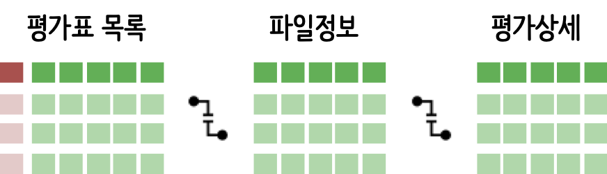

매니페스토 자료구조

## 3.2 데이터 압축풀기 [^1]

압축파일 압출을 푸는 방법 `unzip`, `7za` 등 쉘에서 압축을 푸는 방법으로 문제를 풀어본다. 이를 위해서 쉘 명령어를 사용한다.

```bash
for filename in data/manifesto/*.zip
do
  echo "*** processing $filename ***"
  7za x -y $filename -odata/manifesto
done
```

```bash
ls data/manifesto/ | grep "^2020.*\.hwp$" | tail
```

```
2020공약자체평가표_242.정점식.hwp
2020공약자체평가표_244.민홍철.hwp
2020공약자체평가표_245.김정호.hwp
2020공약자체평가표_250.강석진.hwp
2020공약자체평가표_251.강창일.hwp
2020공약자체평가표_252.오영훈.hwp
2020공약자체평가표_253.위성곤.hwp
2020공약자체평가표_별첨자료.hwp
2020공약자체평가표_공약이행근거자료(최종).hwp
2020의정활동결과표(유성엽).hwp
```

[^1]: [Ask Ubuntu, “7zip destination folder -o”](https://askubuntu.com/questions/615874/7zip-destination-folder-o)